# Visualization of 2019 Bay Wheels Ride

## by Youssef Farahat

## Investigation Overview

> In this investigation, I wanted to look at to the user behaviour characteristics, I focused on weekday, user age, user gender, trip duration, and user type to analyze and understand the usage of bike When, Who, How?

## Dataset Overview

> The forgobike trip data are nearly 180,000 rides that happend in Feburary 2019

## (Visualization 1)

> The average trip duration was around 12 minutes yet there are trips above 100 which led to making the plot unreadable.

> So we should do data transformation to make it easier to read and interpret the data. Below are the plots before/after data transformation.

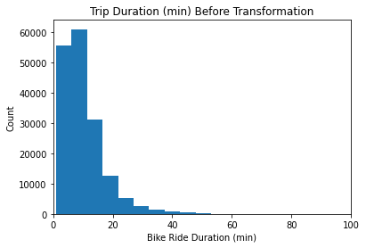

```python
plt.hist(data = df, x = 'duration_minute');
plt.xlim(0, 100);
plt.xlabel("Bike Ride Duration (min)");
plt.ylabel("Count");
plt.title("Trip Duration (min) Before Transformation");
```

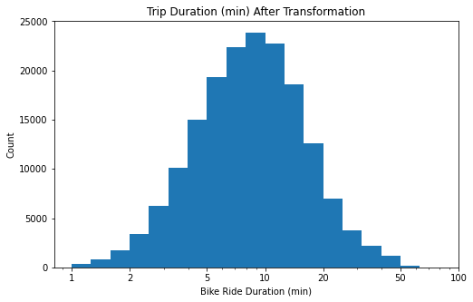

```python
bins = 10 ** np.arange(0, np.log10(df['duration_minute'].max())+0.1, 0.1)

plt.figure(figsize=[8, 5]);
plt.hist(data = df, x = 'duration_minute', bins = bins);
plt.xscale('log');
plt.xticks([1, 2, 5, 10, 20, 50, 100], [1, 2, 5, 10, 20, 50, 100]);
plt.xlabel("Bike Ride Duration (min)");
plt.ylabel("Count");
plt.title("Trip Duration (min) After Transformation");
```

## (Visualization 2)

> Based on our data we have three gender male, female and other. In the next visualization I will show the number of bike rides for each day based on gender

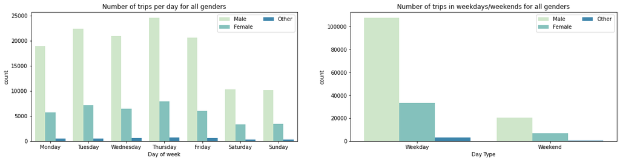

```python
plt.figure(figsize = [20, 10]);

ax = plt.subplot(2, 2, 1);
sb.countplot(data = df, x = 'weekday', hue = 'member_gender', palette = 'GnBu');
ax.legend(loc = 1, ncol = 2);
ax.set_xlabel('Day of week')
plt.title('Number of trips per day for all genders')

ax = plt.subplot(2, 2, 2);
sb.countplot(data = df, x = 'is_weekend', hue = 'member_gender', palette = 'GnBu');
ax.legend(ncol = 2);
ax.set_xlabel('Day Type')
plt.title('Number of trips in weekdays/weekends for all genders');
```

## (Visualization 3)

Based on our data we have two user types. Subscriber, Customer. In the next visualization I will show the number of bike rides for each day based on type

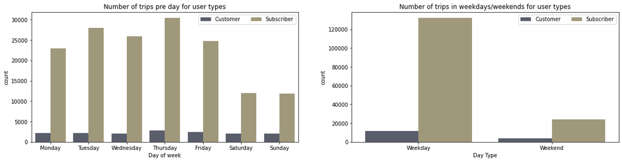

```python
plt.figure(figsize = [20, 10]);

ax = plt.subplot(2, 2, 1)
sb.countplot(data = df, x = 'weekday', hue = 'user_type', palette = 'cividis')
ax.legend(loc = 1, ncol = 2)
ax.set_xlabel('Day of week')
plt.title('Number of trips pre day for user types');

ax = plt.subplot(2, 2, 2)
sb.countplot(data = df, x = 'is_weekend', hue = 'user_type', palette = 'cividis');
ax.legend(loc = 1, ncol = 2)
ax.set_xlabel('Day Type')
plt.title('Number of trips in weekdays/weekends for user types');
```